# countries

Yadu

February 29, 2016

First we load the csv data into R from Github. We also load the required packages.

```r
library(RCurl)
library(tidyr)
library(dplyr)
url = 'https://raw.githubusercontent.com/cyadusha/countries/master/ctyseasonal.csv'
x = getURL(url)
countries = read.csv(file = textConnection(x), header = TRUE)
```

Because we are only interested in the imports and exports for India and Canada, we subset the entire dataset where the country names are either India or Canada. We also select the columns which are titled “year” and the columns which are titled from BJAN to BDEC. These are the months of the year. We do not need the code for each country. Therefore we do not select the column that has country codes.

```r
countries = subset(countries, countries$CTYNAME == 'India'| countries$CTYNAME == 'Canada', select = c(CTYNAME, year, BJAN:BDEC))
```

We name the columns as follows.

```r
colnames(countries) = c("Country", "Year", "January", "February", "March", "April", "May", "June", "July", "August", "September", "October", "November", "December")
```

Now, we gather all of the months into one column. All of the numeric values below the month names are the amount imported by the country. Negative values indicate export.

```r
countries = countries %>%
  gather(Country, Year, January:December, na.rm = F)
```

We name the columns of our new dataset as follows.

```r
colnames(countries) = c("Country", "Year", "Month", "Import")
```

Now, the imports are arranged by country and year. There is no need to arrange it by month. Otherwise each month will be ordered in alphabetical order.

```r
countries %>% arrange(Country, Year)
```

```
##     Country Year     Month Import
## 1    Canada 2009   January -1,791
## 2    Canada 2009  February -1,893
## 3    Canada 2009     March -1,384
## 4    Canada 2009     April -1,092
## 5    Canada 2009       May   -816
## 6    Canada 2009      June -1,854
## 7    Canada 2009      July -2,323
## 8    Canada 2009    August -1,516
## 9    Canada 2009 September -1,787
## 10   Canada 2009   October -2,647
## 11   Canada 2009  November -2,023
## 12   Canada 2009  December -2,465
## 13   Canada 2010   January -3,128
## 14   Canada 2010  February -2,830
```

[output cut: 154 more lines]

Now, we subset our new data set two times. One subset is for performing monthly analysis only for Canada. The other subset is for performing monthly analysis only for India. We arrange the rows in each subset by year.

```r
cCanada = filter(countries, Country == 'Canada') %>% arrange(Year)
```

```r
cIndia = filter(countries, Country == 'India') %>% arrange(Year)
```

Now, we load the ggplot2 package and generate a scatterplot for each country. This scatterplot plots the amount imported over each month.

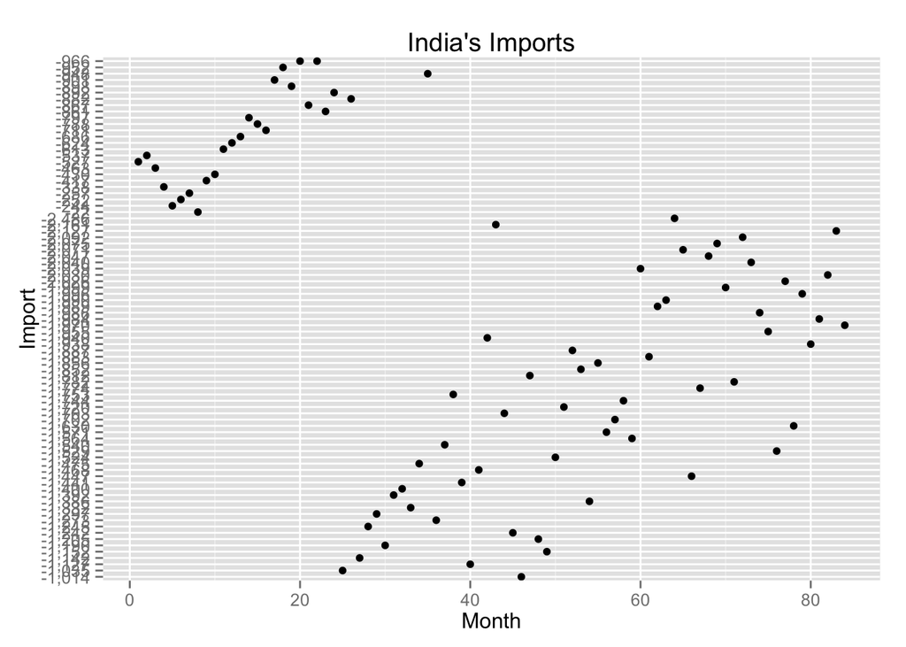

```r
library(ggplot2)
yearmonth = seq(1,84,1)
qplot(yearmonth, cIndia$Import, xlab = "Month", ylab = "Import", main = "India's Imports")
```

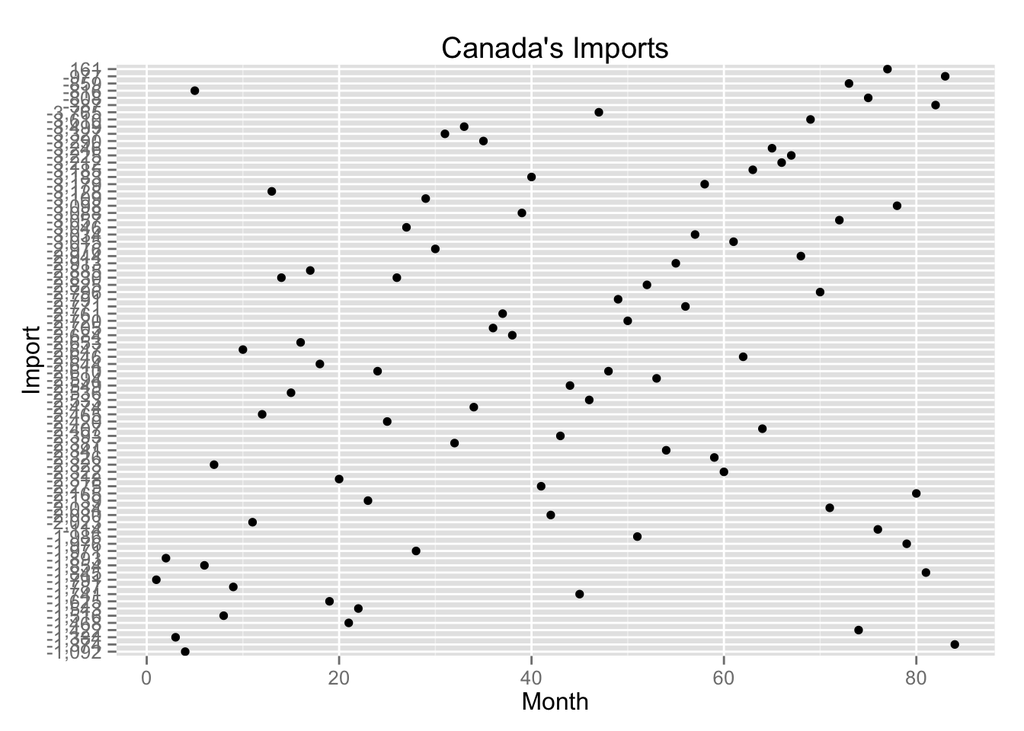

```r
qplot(yearmonth, cCanada$Import, xlab = "Month", ylab = "Import", main = "Canada's Imports")
```

The scatterplot for Canada shows an almost uniform distribution. The export seems to fluctuate between high and low over the time period examined.

However, for both cases, the amount of imports is low. Therefore a favorable balance of trade is maintained for both countries. Import less and export more.